# Analysis

Haojia Li

Zihan Yang

Tianran Zhang

June 21, 2020

# ESP

## Differential Analysis

### Summary

1. The distributions of numeracy scores are significant different in the subgroups of `race` , `hisp` , `education` , `income` , `age.cat`.
2. No matter using not not-poor/poor (corr=0.136, p-value < 0.001) or good/not good(corr=0.175, p-value < 0.001)as the self-reported health status outcome variable, *numeracy score* and self-reported status have positive significant corrrealtion.
3. No matter using not poor/poor or good/not good as the self-reported health status outcome variable, `education` (chisq p-value < 0.001) and `income` (chisq p-value < 0.001) subgroups, and `numeracy score` have the significant effects at the two-sided significance level of 0.05.

### Numeracy

#### Numaracy vs. Binary Vriable

When the ordinal variable has only two levels, wilcoxon test will be performed directly.

##### Numaracy vs. Health Status

`Differential Analysis`  
- numerace vs. health status: good/not good  
There is enough evidence to reject the null hypothesis that the distribution of numeracy scores are the same is good/not good health status subgroup. (p-value < 0.001)

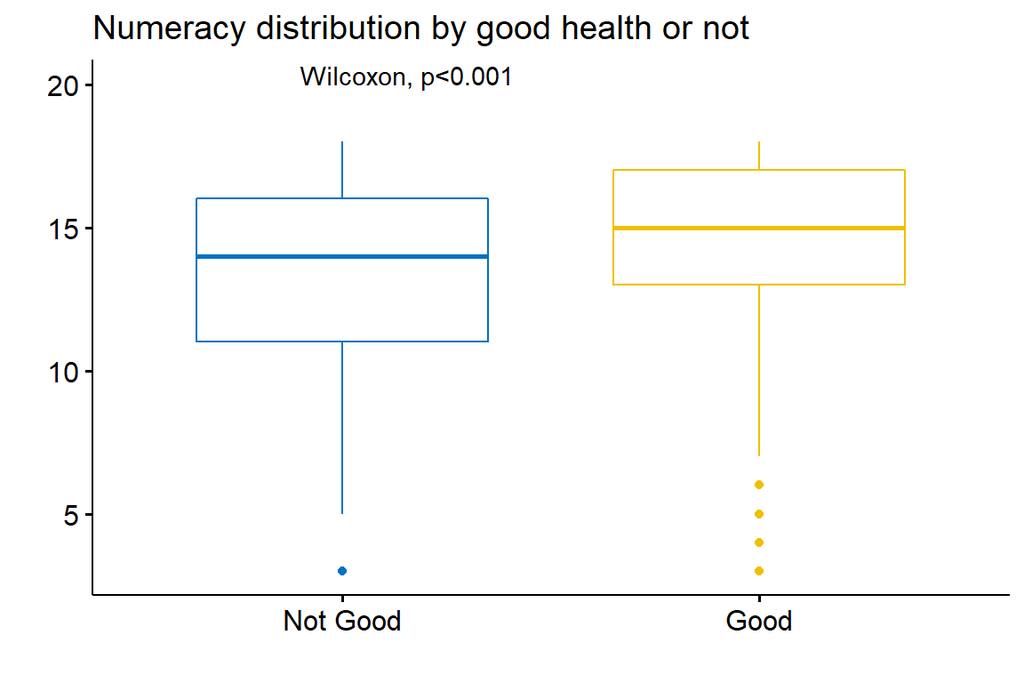

- numeracy vs. health status: not poor/poor  
  There is enough evidence to reject the null hypothesis that the distribution of numeracy scores are the same is not poor/poor health status subgroup. (p-value < 0.001)

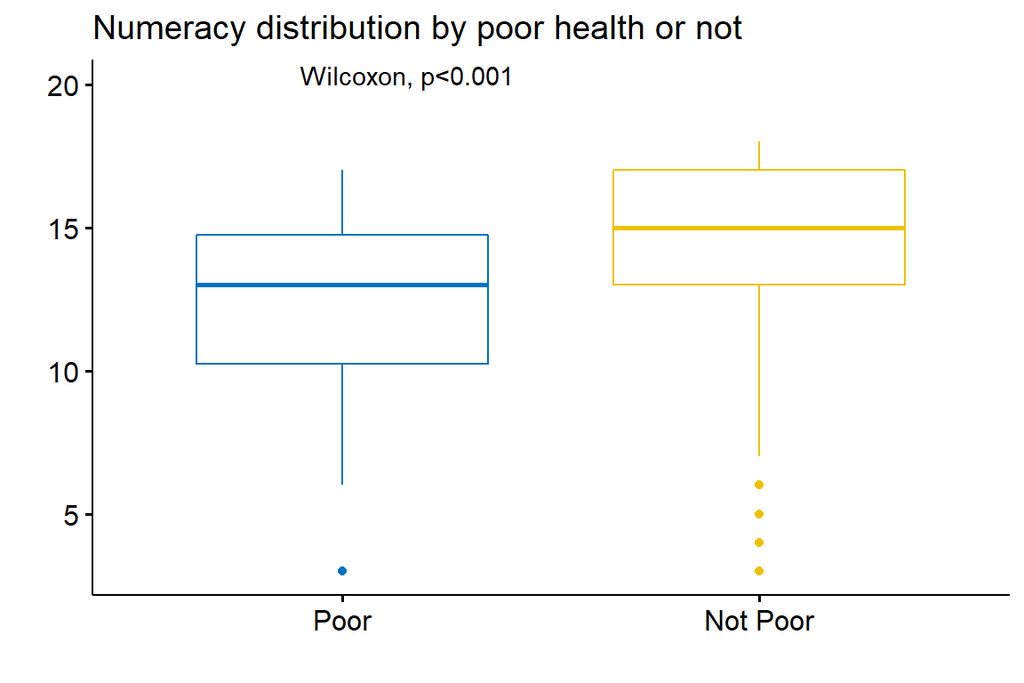

`Correlation`  
[Point-Biserial Correlation](https://en.wikipedia.org/wiki/Point-biserial_correlation_coefficient): 1 continuous variable (numeracy score) and 1 binary variable (health status)

No matter using not not-poor/poor (corr=0.136, p-value < 0.001) or good/not good (corr=0.175, p-value < 0.001)as the self-reported health status outcome variable, numeracy and self-reported status have positive significant corrrealtion.

| Correlation | Point.Biserial.Correlation | P.vale |
| --- | --- | --- |
| Numeracy vs. Poor/Not Poor | 0.13591 | <0.001 |
| Numeracy vs. Good/Not Good | 0.17523 | <0.001 |

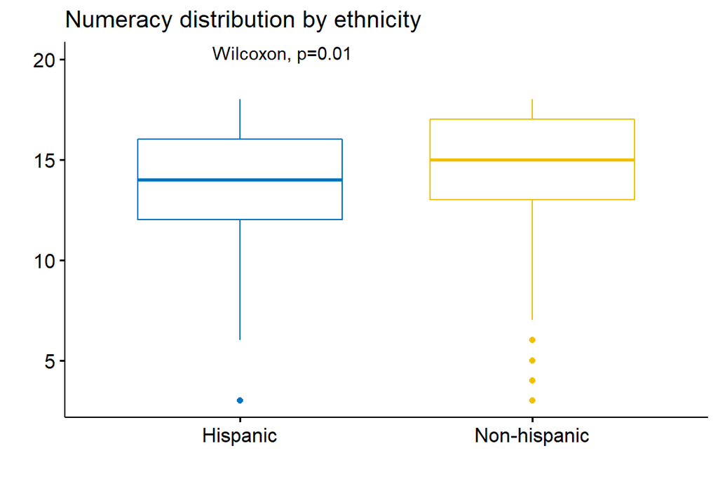

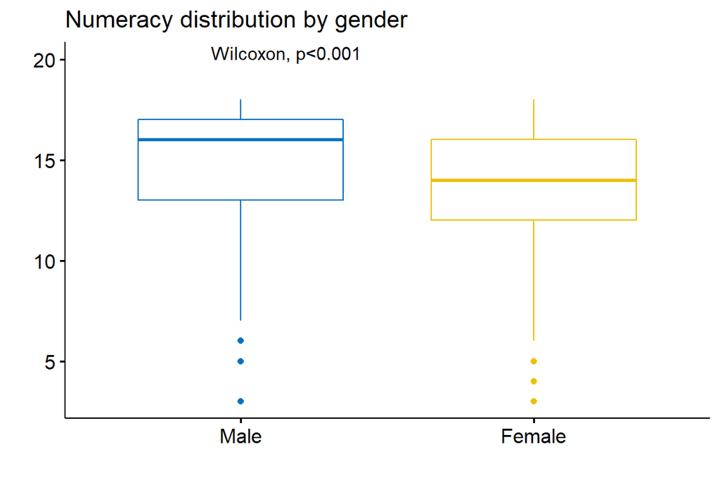

#### Numaracy vs. Multi-level Vriable

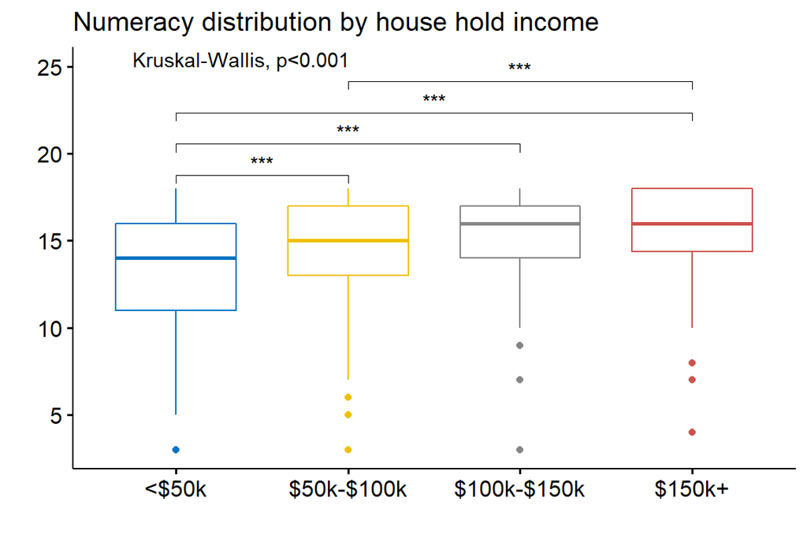

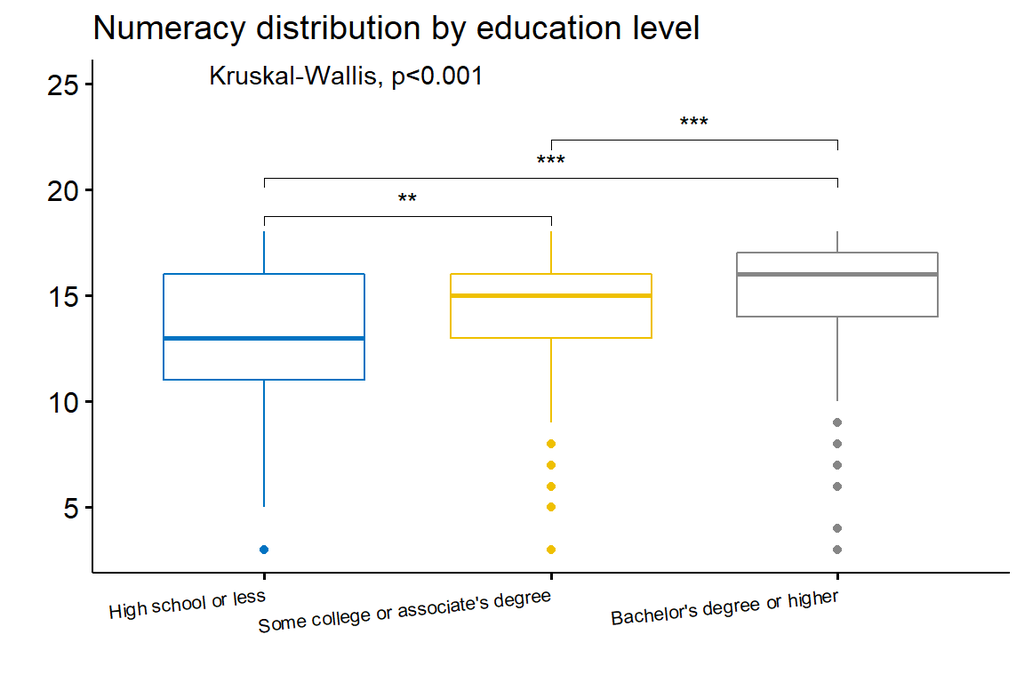

There is enough evidence to reject the null hypothesis that the distribution of numeracy scores are the same in age subgroup. (p-value = 0.02) Specifically, further pairwise comparison indicating that the distribution of numeracy scores are significantly different (age 21-44 vs. age 45-64)(p-value = 0.0069), and a(ge 21-44 vs. age 65+) (p-value = 0.023)

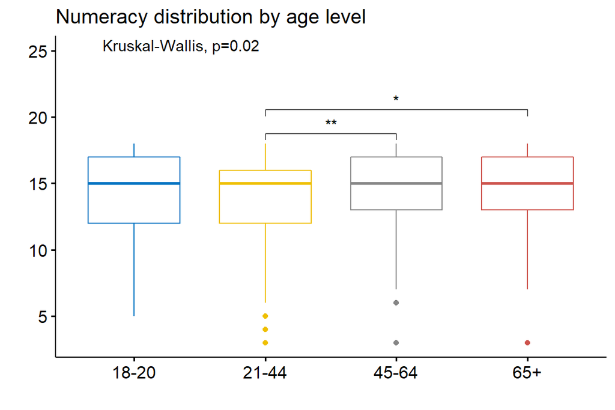

There is enough evidence to reject the null hypothesis that the distribution of numeracy scores are the same in race subgroup. (p-value < 0.001) Specifically, further pairwise comparison indicating that the distribution of numeracy scores are significantly different in white vs. black (p-value < 0.001), and white vs.other (p-value <0.001)

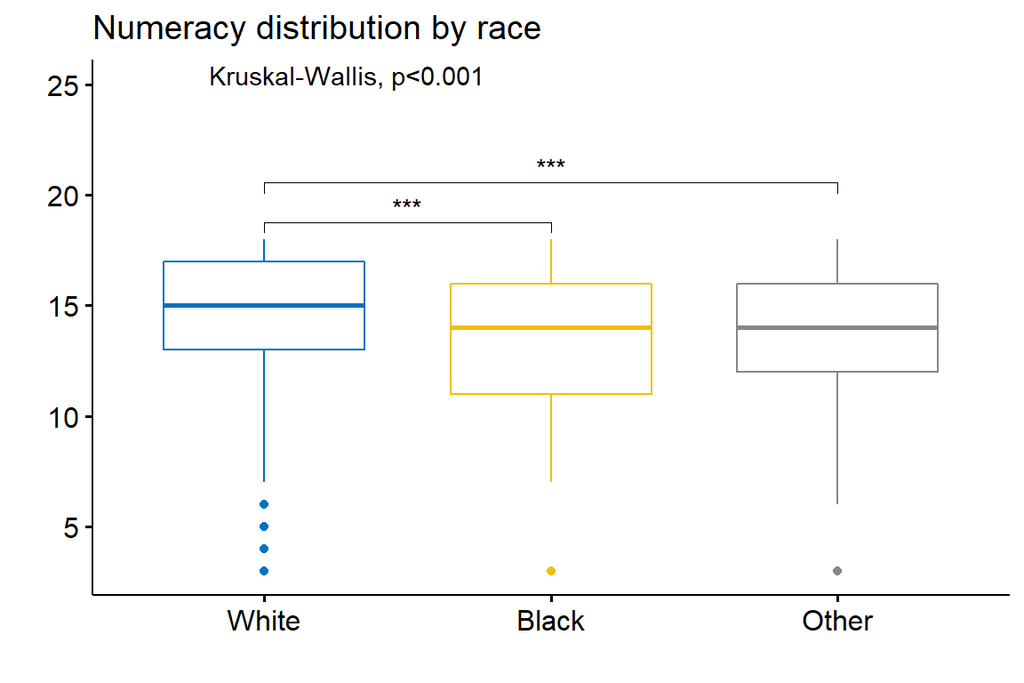

### Health Status

Because all the variables intended to put in the regression are categorical except the numeracy. We would use chisq test to check self-reported health status across different subgroup(gender, age, education, income, race, hisp) seperately.

1. Health status: good/not good  
   There is enough evidence to reject the null hypothesis that the proportions of good self-reported health status are the same among different education subgroups at the two-sided significance level of 0.05.(p-value < 0.001) And there is enough evidence to reject the null hypothesis that the proportions of good self-reported health status are the same among different income subgroups at the two-sided significance level of 0.05. (p-value < 0.001)

Pearson’s Chi-squared Test between Good or Not Good Health Status and Demographical Covarites

|  | Gender | Age | Education | Income | Race | Ethnicity |
| --- | --- | --- | --- | --- | --- | --- |
| P-value | 0.525 | 0.025 | <0.001 | <0.001 | 0.057 | 0.004 |
| Significance |  | * | *** | *** |  | ** |

2. Health status: not poor/poor  
   There is enough evidence to reject the null hypothesis that the proportions of not-poor self-reported health status are the same among different education subgroups at the two-sided significance level of 0.05.(p-value < 0.001) And there is enough evidence to reject the null hypothesis that the proportions of not-poor self-reported health status are the same among different income subgroups at the two-sided significance level of 0.05. (p-value < 0.001)

Pearson’s Chi-squared Test between Not Poor or Poor Health Status and Demographical Covarites

|  | Gender | Age | Education | Income | Race | Ethnicity |
| --- | --- | --- | --- | --- | --- | --- |
| P-value | 0.194 | 0.101 | <0.001 | <0.001 | 0.079 | 0.991 |
| Significance |  |  | *** | *** |  |  |